# Pairs Trading Strategy Using Cointegration

This notebook presents a cointegration-based pairs trading strategy across S&P 500. The goal is to identify cointegrated stock pairs and use a mean-reversion strategy to exploit the arbitrage, and evaluate whether the strategy survives out of sample validation.

We found that the strategy produces strong results in the in-sample period, with a Sharpe ratio of 2.07, but performs significantly worse in the test period, with a Sharpe ratio of only 0.78. This decay is likely attributed to overfitting during pair selection and parameter tuning, as well as structural changes in stock relationships over time. Because pairs are selected using historical relationships from the training period, some of these relationships may weaken or break down in later market regimes.

## 1. Setup

```python
from pathlib import Path

import numpy as np
import pandas as pd
import matplotlib.pyplot as plt
import seaborn as sns

ROOT = Path.cwd().parent if Path.cwd().name == "report" else Path.cwd()
PROCESSED_DATA_PATH = ROOT / "data" / "processed"

INITIAL_CAPITAL = 100_000

pd.set_option("display.max_columns", 100)
sns.set_theme(style="whitegrid")
```

```python
universe = pd.read_csv(PROCESSED_DATA_PATH / "cleaned_universe.csv")
pair_results = pd.read_csv(PROCESSED_DATA_PATH / "pair_results.csv")
selected_pairs = pd.read_csv(PROCESSED_DATA_PATH / "selected_pairs.csv")
signals = pd.read_csv(PROCESSED_DATA_PATH / "signals.csv", parse_dates=["date"])
train_daily = pd.read_csv(PROCESSED_DATA_PATH / "train_backtest_daily_returns.csv", parse_dates=["date"])
validation_daily = pd.read_csv(PROCESSED_DATA_PATH / "validation_backtest_daily_returns.csv", parse_dates=["date"])
test_daily = pd.read_csv(PROCESSED_DATA_PATH / "test_backtest_daily_returns.csv", parse_dates=["date"])
train_metrics = pd.read_csv(PROCESSED_DATA_PATH / "train_backtest_metrics.csv")
validation_metrics = pd.read_csv(PROCESSED_DATA_PATH / "validation_backtest_metrics.csv")
test_metrics = pd.read_csv(PROCESSED_DATA_PATH / "test_backtest_metrics.csv")
validation_results = pd.read_csv(PROCESSED_DATA_PATH / "validation_results.csv")
best_validation_result = pd.read_csv(PROCESSED_DATA_PATH / "best_validation_result.csv")

train_pair_results = pd.read_csv(PROCESSED_DATA_PATH / "train_backtest_pair_results.csv", parse_dates=["date"])
validation_pair_results = pd.read_csv(PROCESSED_DATA_PATH / "validation_backtest_pair_results.csv", parse_dates=["date"])
test_pair_results = pd.read_csv(PROCESSED_DATA_PATH / "test_backtest_pair_results.csv", parse_dates=["date"])
```

## 2. Data and Universe

The universe is constructed by first retrieving the current S&P 500 stocks and download the historical data via yfinance from 2014-01-01 to 2025-12-31. The final cleaned data is split into train, validation, and test periods: train from 2014 to 2019, validation in 2020, and test from 2021 to 2025. We then remove stocks with short histories or excessive missing observations.

```python
universe_summary = pd.DataFrame({
    "num_stocks": [len(universe)],
    "num_sectors": [universe["sector"].nunique()],
    "num_industries": [universe["industry"].nunique()],
})
universe_summary
```

|  | num_stocks | num_sectors | num_industries |
| --- | --- | --- | --- |
| 0 | 456 | 11 | 122 |

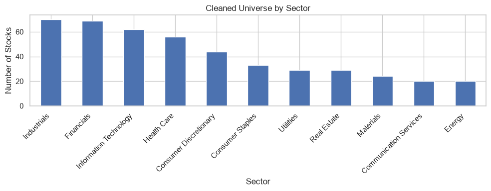

```python
universe["sector"].value_counts().plot(kind="bar", figsize=(10, 4))
plt.title("Cleaned Universe by Sector")
plt.xlabel("Sector")
plt.ylabel("Number of Stocks")
plt.xticks(rotation=45, ha="right")
plt.tight_layout()
```

## 3. Pair Discovery

Pairs are discovered using the Engle-Granger cointegration test on log prices. The hedge ratio is estimated using OLS, and the residual spread is tested with ADF. Pairs are ranked by cointegration p-value, ADF p-value, and half-life.

```python
pair_results.head(10)
```

|  | ticker1 | ticker2 | industry | alpha | beta | coint_pvalue | adf_pvalue | half_life |
| --- | --- | --- | --- | --- | --- | --- | --- | --- |
| 0 | ICE | MSCI | Financial Exchanges & Data | 1.716077 | 0.500062 | 0.000336 | 0.000048 | 24.259501 |
| 1 | FISV | GPN | Transaction & Payment Processing Services | 0.708012 | 0.770858 | 0.001324 | 0.000216 | 28.569795 |
| 2 | AON | WTW | Insurance Brokers | -1.826164 | 1.365216 | 0.001449 | 0.000238 | 22.853350 |
| 3 | MRK | VTRS | Pharmaceuticals | 5.504342 | -0.494337 | 0.002060 | 0.000350 | 30.376482 |
| 4 | BAC | TFC | Diversified Banks | -2.620294 | 1.617766 | 0.003199 | 0.000572 | 30.363206 |
| 5 | NXPI | SWKS | Semiconductors | 1.643804 | 0.660081 | 0.003516 | 0.000636 | 25.404381 |
| 6 | ICE | SPGI | Financial Exchanges & Data | 0.556015 | 0.705972 | 0.004061 | 0.000747 | 31.909897 |
| 7 | DHI | NVR | Homebuilding | -1.920156 | 0.700208 | 0.004125 | 0.000760 | 25.901720 |
| 8 | NDSN | PH | Industrial Machinery & Supplies & Components | -1.416824 | 1.234954 | 0.004467 | 0.000830 | 29.637800 |
| 9 | TECH | TMO | Life Sciences Tools & Services | -1.693252 | 0.987972 | 0.004598 | 0.000857 | 30.249084 |

```python
selected_pairs
```

|  | ticker1 | ticker2 | industry | alpha | beta | coint_pvalue | adf_pvalue | half_life |
| --- | --- | --- | --- | --- | --- | --- | --- | --- |
| 0 | ICE | MSCI | Financial Exchanges & Data | 1.716077 | 0.500062 | 0.000336 | 0.000048 | 24.259501 |
| 1 | FISV | GPN | Transaction & Payment Processing Services | 0.708012 | 0.770858 | 0.001324 | 0.000216 | 28.569795 |
| 2 | AON | WTW | Insurance Brokers | -1.826164 | 1.365216 | 0.001449 | 0.000238 | 22.853350 |
| 3 | BAC | TFC | Diversified Banks | -2.620294 | 1.617766 | 0.003199 | 0.000572 | 30.363206 |
| 4 | NXPI | SWKS | Semiconductors | 1.643804 | 0.660081 | 0.003516 | 0.000636 | 25.404381 |
| 5 | ICE | SPGI | Financial Exchanges & Data | 0.556015 | 0.705972 | 0.004061 | 0.000747 | 31.909897 |
| 6 | DHI | NVR | Homebuilding | -1.920156 | 0.700208 | 0.004125 | 0.000760 | 25.901720 |
| 7 | NDSN | PH | Industrial Machinery & Supplies & Components | -1.416824 | 1.234954 | 0.004467 | 0.000830 | 29.637800 |
| 8 | TECH | TMO | Life Sciences Tools & Services | -1.693252 | 0.987972 | 0.004598 | 0.000857 | 30.249084 |
| 9 | FITB | RF | Regional Banks | 1.178775 | 0.757139 | 0.005908 | 0.001137 | 31.633815 |
| 10 | EW | MDT | Health Care Equipment | -7.197383 | 2.581704 | 0.006292 | 0.001222 | 28.595010 |
| 11 | ORCL | SNPS | Application Software | 2.187178 | 0.350104 | 0.006679 | 0.001306 | 32.583715 |
| 12 | EIX | PPL | Electric Utilities | 0.353789 | 1.116875 | 0.006977 | 0.001367 | 38.504052 |
| 13 | PPG | SHW | Specialty Chemicals | 3.300859 | 0.259968 | 0.007626 | 0.001519 | 31.294520 |
| 14 | AEP | WEC | Electric Utilities | 0.520129 | 0.880979 | 0.008394 | 0.001690 | 27.516238 |
| 15 | ES | WEC | Electric Utilities | 0.494619 | 0.850403 | 0.008776 | 0.001780 | 32.685330 |
| 16 | ISRG | RVTY | Health Care Equipment | -2.770407 | 1.780767 | 0.008810 | 0.001787 | 33.877054 |
| 17 | CRL | WAT | Life Sciences Tools & Services | -0.935715 | 1.075628 | 0.009028 | 0.001838 | 29.928894 |
| 18 | DRI | DPZ | Restaurants | 0.122134 | 0.793028 | 0.010714 | 0.002232 | 36.142859 |
| 19 | CME | ICE | Financial Exchanges & Data | -1.147902 | 1.410233 | 0.011385 | 0.002390 | 32.013590 |

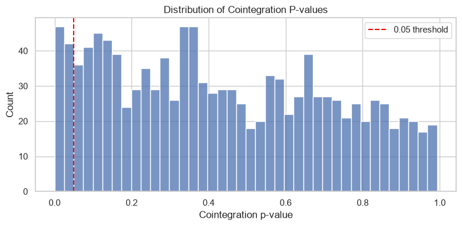

```python
plt.figure(figsize=(8, 4))
sns.histplot(pair_results["coint_pvalue"], bins=40)
plt.axvline(0.05, color="red", linestyle="--", label="0.05 threshold")
plt.title("Distribution of Cointegration P-values")
plt.xlabel("Cointegration p-value")
plt.ylabel("Count")
plt.legend()
plt.tight_layout()
```

## 4. Signal Construction

The spread is defined as:

$$spread_t = log(P_y)_t - alpha - beta \cdot log(P_x)_t$$

The z-score normalizes the spread using a rolling mean and rolling standard deviation. Signals are lagged by one day so that trades only use observable information. We enter a position for a pair once its z-score exceeds the entry threshold and hold that position until the z-score falls below the exit threshold or exceeds the stop-loss cap.

```python
signals.groupby(["period", "signal"]).size().unstack(fill_value=0)
```

| signal period | -1 | 0 | 1 |
| --- | --- | --- | --- |
| test | 3869 | 16375 | 3616 |
| train | 3992 | 21070 | 3938 |
| validation | 414 | 2983 | 463 |

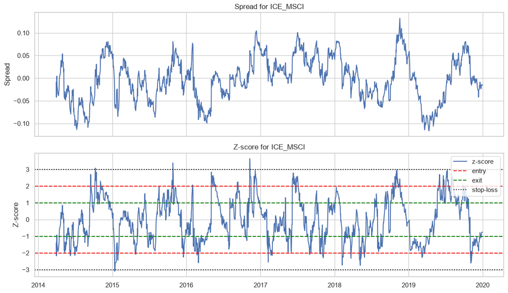

```python
entry_z = best_validation_result["entry_z"].iloc[0]
exit_z = best_validation_result["exit_z"].iloc[0]
stop_loss_z = best_validation_result["stop_loss_z"].iloc[0]

example_pair = selected_pairs.iloc[0]["ticker1"] + "_" + selected_pairs.iloc[0]["ticker2"]
example_signals = signals[(signals["period"] == "train") & (signals["pair"] == example_pair)].copy()

fig, axes = plt.subplots(2, 1, figsize=(12, 7), sharex=True)
axes[0].plot(example_signals["date"], example_signals["spread"])
axes[0].set_title(f"Spread for {example_pair}")
axes[0].set_ylabel("Spread")

axes[1].plot(example_signals["date"], example_signals["z_score"], label="z-score")
axes[1].axhline(entry_z, color="red", linestyle="--", label="entry")
axes[1].axhline(-entry_z, color="red", linestyle="--")
axes[1].axhline(exit_z, color="green", linestyle="--", label="exit")
axes[1].axhline(-exit_z, color="green", linestyle="--")
axes[1].axhline(stop_loss_z, color="black", linestyle=":", label="stop-loss")
axes[1].axhline(-stop_loss_z, color="black", linestyle=":")
axes[1].set_title(f"Z-score for {example_pair}")
axes[1].set_ylabel("Z-score")
axes[1].legend(loc="upper right")

plt.tight_layout()
```

## 5. Backtest Results

The strategy uses fixed gross exposure per pair and applies transaction costs to dollar turnover. Results are reported separately for train, validation, and test periods.

```python
metrics = pd.concat([train_metrics, validation_metrics, test_metrics], ignore_index=True)
metrics
```

|  | period | total_return | annualized_return | annualized_volatility | sharpe_ratio | max_drawdown | total_cost |
| --- | --- | --- | --- | --- | --- | --- | --- |
| 0 | train | 0.180894 | 0.031438 | 0.015154 | 2.074586 | -0.011495 | 2187.0 |
| 1 | validation | 0.037932 | 0.049528 | 0.020652 | 2.398268 | -0.008768 | 240.0 |
| 2 | test | 0.076541 | 0.016168 | 0.020626 | 0.783862 | -0.019869 | 1777.5 |

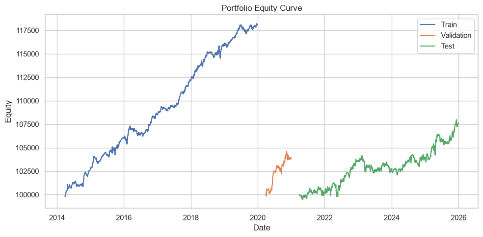

```python
plt.figure(figsize=(10, 5))
plt.plot(train_daily["date"], train_daily["equity"], label="Train")
plt.plot(validation_daily["date"], validation_daily["equity"], label="Validation")
plt.plot(test_daily["date"], test_daily["equity"], label="Test")
plt.title("Portfolio Equity Curve")
plt.xlabel("Date")
plt.ylabel("Equity")
plt.legend()
plt.tight_layout()
```

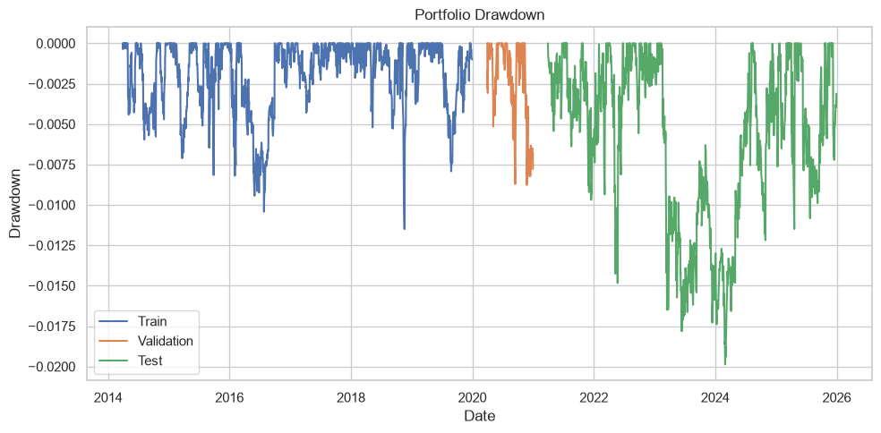

```python
plt.figure(figsize=(10, 5))
plt.plot(train_daily["date"], train_daily["drawdown"], label="Train")
plt.plot(validation_daily["date"], validation_daily["drawdown"], label="Validation")
plt.plot(test_daily["date"], test_daily["drawdown"], label="Test")
plt.title("Portfolio Drawdown")
plt.xlabel("Date")
plt.ylabel("Drawdown")
plt.legend()
plt.tight_layout()
```

```python
cost_rate = best_validation_result["transaction_cost"].iloc[0]

summary_rows = []
for period, daily in [("train", train_daily), ("validation", validation_daily), ("test", test_daily)]:
    summary_rows.append({
        "period": period,
        "daily_win_rate": (daily["net_pnl"] > 0).mean(),
        "average_daily_return": daily["daily_return"].mean(),
        "average_daily_turnover": (daily["cost"] / cost_rate).mean() / INITIAL_CAPITAL,
        "average_exposure": daily["exposure"].mean() / INITIAL_CAPITAL,
    })

pd.DataFrame(summary_rows)
```

|  | period | daily_win_rate | average_daily_return | average_daily_turnover | average_exposure |
| --- | --- | --- | --- | --- | --- |
| 0 | train | 0.559310 | 0.000125 | 0.050276 | 0.273448 |
| 1 | validation | 0.559585 | 0.000197 | 0.041451 | 0.227202 |
| 2 | test | 0.518860 | 0.000064 | 0.049665 | 0.313705 |

## 6. Parameter Sensitivity

The validation grid tests sensitivity to lookback window, entry threshold, exit threshold, stop-loss threshold, and transaction cost. The goal is to find the best parameter set, as well as to check whether performance is stable across nearby parameter choices.

```python
best_validation_result
```

|  | lookback_window | entry_z | exit_z | stop_loss_z | transaction_cost | train_total_return | train_annualized_return | train_annualized_volatility | train_sharpe_ratio | train_max_drawdown | train_total_cost | validation_total_return | validation_annualized_return | validation_annualized_volatility | validation_sharpe_ratio | validation_max_drawdown | validation_total_cost | test_total_return | test_annualized_return | test_annualized_volatility | test_sharpe_ratio | test_max_drawdown | test_total_cost |
| --- | --- | --- | --- | --- | --- | --- | --- | --- | --- | --- | --- | --- | --- | --- | --- | --- | --- | --- | --- | --- | --- | --- | --- |
| 0 | 60.0 | 2.0 | 1.0 | 3.0 | 0.0003 | 0.180894 | 0.031438 | 0.015154 | 2.074586 | -0.011495 | 2187.0 | 0.037932 | 0.049528 | 0.020652 | 2.398268 | -0.008768 | 240.0 | 0.076541 | 0.016168 | 0.020626 | 0.783862 | -0.019869 | 1777.5 |

```python
validation_results.sort_values("validation_sharpe_ratio", ascending=False).head(10)
```

|  | lookback_window | entry_z | exit_z | stop_loss_z | transaction_cost | train_total_return | train_annualized_return | train_annualized_volatility | train_sharpe_ratio | train_max_drawdown | train_total_cost | validation_total_return | validation_annualized_return | validation_annualized_volatility | validation_sharpe_ratio | validation_max_drawdown | validation_total_cost | test_total_return | test_annualized_return | test_annualized_volatility | test_sharpe_ratio | test_max_drawdown | test_total_cost |
| --- | --- | --- | --- | --- | --- | --- | --- | --- | --- | --- | --- | --- | --- | --- | --- | --- | --- | --- | --- | --- | --- | --- | --- |
| 0 | 60 | 2.0 | 1.0 | 3.0 | 0.0001 | 0.195474 | 0.033972 | 0.015160 | 2.240948 | -0.011258 | 729.0 | 0.039532 | 0.051618 | 0.020660 | 2.498487 | -0.008699 | 80.0 | 0.088391 | 0.018671 | 0.020632 | 0.904957 | -0.017417 | 592.5 |
| 1 | 60 | 2.0 | 1.0 | 3.0 | 0.0003 | 0.180894 | 0.031438 | 0.015154 | 2.074586 | -0.011495 | 2187.0 | 0.037932 | 0.049528 | 0.020652 | 2.398268 | -0.008768 | 240.0 | 0.076541 | 0.016168 | 0.020626 | 0.783862 | -0.019869 | 1777.5 |
| 2 | 60 | 2.0 | 1.0 | 3.5 | 0.0001 | 0.212844 | 0.036991 | 0.015666 | 2.361202 | -0.010778 | 649.0 | 0.038373 | 0.050104 | 0.021512 | 2.329105 | -0.009839 | 76.0 | 0.089199 | 0.018842 | 0.021387 | 0.880987 | -0.013881 | 526.5 |
| 3 | 60 | 2.0 | 1.0 | 3.0 | 0.0005 | 0.166314 | 0.028904 | 0.015150 | 1.907863 | -0.011736 | 3645.0 | 0.036332 | 0.047439 | 0.020645 | 2.297828 | -0.008976 | 400.0 | 0.064691 | 0.013665 | 0.020621 | 0.662652 | -0.022343 | 2962.5 |
| 4 | 60 | 2.0 | 1.0 | 3.5 | 0.0003 | 0.199864 | 0.034735 | 0.015661 | 2.217874 | -0.010928 | 1947.0 | 0.036853 | 0.048119 | 0.021496 | 2.238548 | -0.009985 | 228.0 | 0.078669 | 0.016617 | 0.021385 | 0.777068 | -0.014360 | 1579.5 |
| 5 | 60 | 2.0 | 1.0 | 3.5 | 0.0005 | 0.186884 | 0.032479 | 0.015658 | 2.074258 | -0.011080 | 3245.0 | 0.035333 | 0.046134 | 0.021481 | 2.147715 | -0.010182 | 380.0 | 0.068139 | 0.014393 | 0.021384 | 0.673089 | -0.014845 | 2632.5 |
| 6 | 60 | 2.5 | 1.0 | 3.0 | 0.0001 | 0.119167 | 0.020710 | 0.010819 | 1.914300 | -0.010162 | 381.5 | 0.014830 | 0.019363 | 0.011555 | 1.675690 | -0.006344 | 38.5 | 0.046228 | 0.009765 | 0.014979 | 0.651917 | -0.020085 | 336.0 |
| 7 | 60 | 2.5 | 1.0 | 3.0 | 0.0003 | 0.111537 | 0.019384 | 0.010816 | 1.792238 | -0.010310 | 1144.5 | 0.014060 | 0.018357 | 0.011558 | 1.588285 | -0.006436 | 115.5 | 0.039508 | 0.008345 | 0.014978 | 0.557159 | -0.021797 | 1008.0 |
| 8 | 60 | 2.0 | 0.5 | 3.0 | 0.0001 | 0.243157 | 0.042259 | 0.017730 | 2.383425 | -0.012742 | 641.0 | 0.030306 | 0.039570 | 0.025687 | 1.540465 | -0.011832 | 67.5 | 0.113365 | 0.023946 | 0.025214 | 0.949721 | -0.022149 | 531.0 |
| 9 | 60 | 2.5 | 1.0 | 3.0 | 0.0005 | 0.103907 | 0.018058 | 0.010814 | 1.669894 | -0.010459 | 1907.5 | 0.013290 | 0.017352 | 0.011562 | 1.500800 | -0.006528 | 192.5 | 0.032788 | 0.006926 | 0.014979 | 0.462368 | -0.024261 | 1680.0 |

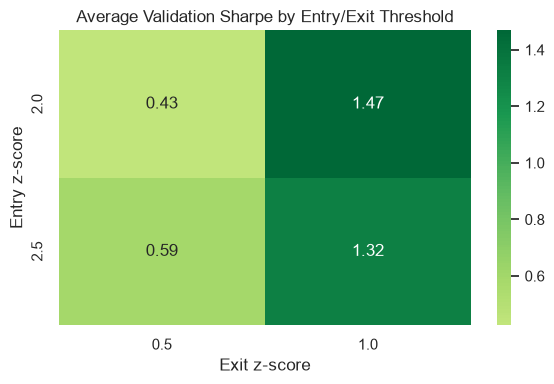

```python
baseline_cost = best_validation_result["transaction_cost"].iloc[0]
baseline_grid = validation_results[validation_results["transaction_cost"] == baseline_cost].copy()

heatmap_data = baseline_grid.pivot_table(
    index="entry_z",
    columns="exit_z",
    values="validation_sharpe_ratio",
    aggfunc="mean",
)

plt.figure(figsize=(6, 4))
sns.heatmap(heatmap_data, annot=True, fmt=".2f", cmap="RdYlGn", center=0)
plt.title("Average Validation Sharpe by Entry/Exit Threshold")
plt.xlabel("Exit z-score")
plt.ylabel("Entry z-score")
plt.tight_layout()
```

## 7. Out-of-Sample Validation

The validation period is used to select parameters. The test period is kept separate as the final out-of-sample check.

```python
comparison = metrics.set_index("period")[[
    "total_return",
    "annualized_return",
    "annualized_volatility",
    "sharpe_ratio",
    "max_drawdown",
    "total_cost",
]]
comparison
```

| period | total_return | annualized_return | annualized_volatility | sharpe_ratio | max_drawdown | total_cost |
| --- | --- | --- | --- | --- | --- | --- |
| train | 0.180894 | 0.031438 | 0.015154 | 2.074586 | -0.011495 | 2187.0 |
| validation | 0.037932 | 0.049528 | 0.020652 | 2.398268 | -0.008768 | 240.0 |
| test | 0.076541 | 0.016168 | 0.020626 | 0.783862 | -0.019869 | 1777.5 |

## 8. Conclusion and Limitations

The cointegration-based pair trading strategy exhibits a very strong performance during the in-sample period, but it decays during the out-of-sample period, which is likely attributed to overfitting during pair selection and parameter tuning and structural changes in stock relationships over time.

There are several limitations associated with the project. The universe is based on the current S&P 500 constituents, so the backtest excludes firms that were removed from the index during the sample period. This leads to survivorship bias that may make results look better than in real time. Additionally, we use a static hedge ratio, but the relationship between two stocks can change over time, so a rolling beta may be more realistic.